# Machine Learning Course Project

Luca Vignali

13 luglio 2015

## Introduction

Outcome is the “classe” variable, predict with any of the other variables.

## Training Set description and feature selection

The Training set includes 19622 observation of 159 variables plus the outcome: the classe variable. Out of 159 variables, the columns 1 to 7 are removed in training_2 data as they can’t be considered predictors as they are not measures from the measurements equipments.

Finally we detect with summary function, that the 33 variables have 19216 empty cases. For the same reason above, we remove those variables and generate training_4, which includes 19622 observations of 52 variables that will be used as predictors and 1 outcome.

```r
library(mice)
training <- read.csv("pml-training.csv")

training_2 <- training[,-c(1:7)]
md.pattern(training_2)

na_col <- apply(training_2, 2, na_num <- function(x) {sum(is.na(x))})
i_na_col <- na_col == 0
training_3 <- training_2[,i_na_col]
summary(training_3)

empty_col <- apply(training_3, 2, empty_f <- function(x) {sum(x == "")})
i_col2 <- empty_col == 0
training_4 <- training_3[,i_col2]
```

## Models Creation and Cross Validation

In this chapter we explain how built the prediction models utilizing all 52 available predictors. The model have been selected from the ones explained during the course “Practical Machine Learning”. We will use Accuracy estimated through cross validation to select the best model.

As the classe variable is categorical, including 5 possible values (A,B,C,D), we don’t utilize regression models. The simplest model we use is the Tree Classification based on rpart package.

### Simple Tree Model (CART)

The first tree model, train_tree, is generated with standard tuneLength caret package values = 3, applying Cross Validation with standard k-fold mthod with k = 10. The obtain model is optimized with complexity parameter cp=0.036 and provides a 51% Accuracy estimated through cross validation. In order to increase accuracy, we create a more complex tree, train_tree_tL100, by increasing to 100 the tuneLength value, that is optimized with complexity parameter cp = 0, and Accuracy = 94%. As the cp value is at the minimum, we don’t explore anymore basic tree modelling, but in the next chapter we will explore the impact of pre-processing on this model.

```r
library(caret)
library(rpart)
str(training$classe)
set.seed(1803)
traincontrol <- trainControl(method = "cv")
train_tree <- train(classe ~ ., data = training_4, method = "rpart",
                       trControl = traincontrol)
train_tree

set.seed(1803)
traincontrol <- trainControl(method = "cv")
train_tree_tL100 <- train(classe ~ ., data = training_4, method = "rpart",
                           trControl = traincontrol, tuneLength = 100)
train_tree_tL100
```

#### Pre-Processing with Center and Scale

We apply simple Centering and Scaling to the training_4 training set and we evaluate the impact on the best performing model created in the previous paragraph. The obtained train_tree_tL100_cs is optimized with cp = 0, the estimated Accuracy is = 94% as in the previous model. So there is no clear advantage to apply the Center and Scale pre-processing.

```r
set.seed(1803)
traincontrol <- trainControl(method = "cv")
train_tree_tL100_cs <- train(classe ~ ., data = training_4, method = "rpart",
                          trControl = traincontrol, tuneLength = 100,
                          preProcess = c("center", "scale"))
train_tree_tL100_cs
```

#### Pre-Processing with Principal Component Analysis

We new evaluate the impact of Principal Component Analysis (PCA) on Accuracy in the training_4 data set. The obtained train_tree_tL100_pca is optimized with cp = 0, as the previous model, the estimated Accuracy is = 82%. As the estimated Standard Deviation of the Accuracy is about 1%, we can conlude that the PCA is reducing Acuracy.

```r
set.seed(1803)
traincontrol <- trainControl(method = "cv")
train_tree_tL100_pca <- train(classe ~ ., data = training_4, method = "rpart",
                          trControl = traincontrol, tuneLength = 100,
                          preProcess = "pca")
train_tree_tL100_pca
```

### Random Forest Model

The second model we build is train_forest biult from Random Forest based on “rf”" package utilized through “caret” package.The tuning parameter is mtry number of variable randomly selected for each tree. All parameters are standard, including the k-fold = 10 for Cross Validation. The best result based on Accuracy is obtain with Randomly Selected Predictors = 2. The Accuracy is about 99.5%. We don’t apply any preprocessing to this model as pca and center and scale didn’t imporve accuracy in the tree based models.

```r
set.seed(1803)
library(randomForest)
traincontrol <- trainControl(method = "cv")
train_forest <- train(classe ~ ., data = training_4, method ="rf",
                      trControl = traincontrol)
train_forest
```

### Bagging Model

The third and last model we build is train_bagFDA, obtained through caret package based on earth and mda packages to perform Flexible Discriminant Analysis. The tuning parameter is the degree (complexity of the models combination) and nprune to prune the trees. All parameter are caret standard including k-fold = 10 for cross validation. The caret output model train_badFDA, has beed obtained with constant degree = 1 and nprune = 17, providing accuracy of about 69%.

```r
set.seed(1803)
traincontrol <- trainControl(method = "cv")
train_bagFDA <- train(classe ~ ., data = training_4, method ="bagFDA",
                      trControl = traincontrol)
train_bagFDA
```

## Cross Validation - Out of Sample Error

In the previous paragraph we created several ML models and tested them using k-fold Cross Validation Technique. In all casses we selected the caret default k=10. The analyzed ML model type are:

- Tree based.
- Tree based with Center and Scale pre-processing.
- Tree based with Principal Component Analysis pre-processing.
- Random Forest.
- Bagging.

For each model type we created several models based on tuning parameters, and compared them based on Accuracy estimated through Cross Validation. The tuning parameters depends on the model. In the following table we summarize all the models and tuning parameters we analyzed in the previous paragraph.

| Model | Tuning Parameters |
| --- | --- |
| Tree | Complexity Parameter (cp) - 3 values |
| Tree100 | Complexity Parameter (cp) - 100 values |
| Tree100 CS | Complexity Parameter (cp) - 100 Values |
| Tree100 PCA | Complexity Parameter (cp) - 100 Values |
| Random Forest | Randomly Selected Predictors (mtry) - 3 Values |
| Bagging FDA | Tree Pruning parameter (nprune) - 3 Values |

All the models are then evaluated through k-fold Cross Validation to obtain Accuracy and Accuracy Standard Deviation. As explained in the next chapter.

The out of Sample Error is estimated in terms of Accuracy with the k-fold Cross Validation, with k=10 as standard value in caret package. The obtained Accuracy are shown in the following picture.

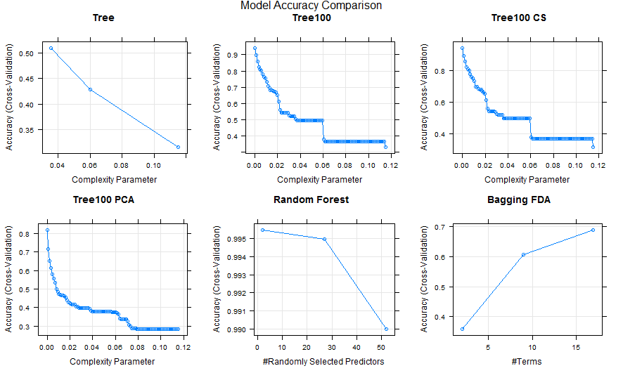

```r
library(ggplot2)
library(gridExtra)
plot_tree <- plot(train_tree, main = "Tree")
plot_tree_100 <- plot(train_tree_tL100, main = "Tree100")
plot_tree_100_cs <- plot(train_tree_tL100_cs, main = "Tree100 CS")
plot_tree_100_pca <- plot(train_tree_tL100_pca, main = "Tree100 PCA")
plot_forest <- plot(train_forest, main = "Random Forest")
plot_bagging <- plot(train_bagFDA, main = "Bagging FDA")

grid.arrange(plot_tree,plot_tree_100, plot_tree_100_cs, plot_tree_100_pca, plot_forest, plot_bagging,ncol=3, nrow = 2, main = "Model Accuracy Comparison")
```

The picture above shows the Accuracy as a function of the caret tuning parameter, that depends on the model type. For each tuned model we select the tuning parameter that miximizes Accuracy, as reported in the following table where awe added the Accuracy Standard Deviation to have a measure of the Accuracy precision.

| Model | Best Tuning Parameter Value | Accuracy | Accuracy Standard Deviation |
| --- | --- | --- | --- |
| Tree | Complexity Parameter (cp) = 0.036 | 51% | 2% |
| Tree100 | Complexity Parameter (cp) = 0 | 94% | 0.4% |
| Tree100 CS | Complexity Parameter (cp) = 0 | 94% | 0.4% |
| Tree100 PCA | Complexity Parameter (cp) = 0 | 82% | 1.2% |
| Random Forest | Randomly Selected Predictors (mtry) = 2 | 99.5% | 0.2% |
| Bagging FDA | Tree Pruning parameter (nprune) = 17 | 69% | 1.1% |

## Selected Model and 20 test cases prediction

According to the result showed in the previous chapter, we select the model with highest Accuracy, that is the **Random Forest**. This model is estimated, through **Cross validation**, to provide an **Accuracy of 99.5% with a Standard Deviation of 0.2%**.

In this chapter we apply the selected model to the test data set, that consists of 20 observations. Before applying the model, we must process the test data selecting only the features we included in the training set. The resulting test set is testing_2 including 52 features and 20 observation with no NA values.

```r
testing <- read.csv("pml-testing.csv")

n_col <- names(training_4[,-53])
testing_2 <- testing[,n_col]
sum(is.na(testing_2))


pred_classe <- predict(train_forest, newdata = testing_2)
```

The model applied to the testing_2 data, provides the outcome with 5 possible levels (“A”, “B”, “C”, “D”, “E”). The outcome is as follows, ordered according to observation order in testing_2. Predicted Classe: **1.B 2.A 3.B 4.A 5.A 6.E 7.D 8.B 9.A 10.A 11.B 12.C 13.B 14.A 15.E 16.E 17.A 18.B 19.B 20.B**.

## Precict the 20 cases of test set

You should also apply your machine learning algorithm to the 20 test cases available in the test data above. Please submit your predictions in appropriate format to the programming assignment for automated grading. See the programming assignment for additional details.

Submission should consist of a link to a Github repo with your R markdown and compiled HTML file describing your analysis. Constrain the text of the writeup to < 2000 words and the number of figures to be less than 5. It will make it easier for the graders if you submit a repo with a gh-pages branch so the HTML page can be viewed online (and you always want to make it easy on graders :-).

## Evaluation Criteria

- Has the student submitted a github repo?
- Does the submission build a machine learning algorithm to predict activity quality from activity monitors?
- Do the authors describe what they expect the out of sample error to be and estimate the error appropriately with cross-validation?